# Deer Reproduction & Disease Control: Statistical Analyses (part 4)

*Damian Satterthwaite-Phillips*

### Fetal Sex Ratios

Here we model the proportion of males to females among the fetuses. This can be thought of as a binomial distribution, where there is a certain probability of any fetus being a male. Hence, we model this as a GLM with a binomially distributed response, with the (default) logit link function.

```r
sr.glm.full = glm(cbind(maleNo, femaleNo) ~
                  (age + intensity + I(intensity^2) + yearF + cwd)^2 -
                  intensity:I(intensity^2) + section,
                  family = binomial, data = deerF1)
sr.glm = step(sr.glm.full, direction = 'both', trace = 0)
```

```
## Error in step(sr.glm.full, direction = "both", trace = 0): number of rows in use has changed: remove missing values?
```

```r
sr.glm.full = glm(cbind(maleNo, femaleNo) ~
                  (age + intensity + I(intensity^2) + yearF + cwd)^2 -
                  intensity:I(intensity^2) - age:yearF - I(intensity^2):yearF -
                  age:intensity - age:cwd - age:I(intensity^2) - age -
                  intensity:cwd - intensity:yearF - yearF:cwd - yearF,
                  family = binomial, data = deerF1)
sr.glm = step(sr.glm.full, direction = 'both', trace = 0)
summary(sr.glm)
```

```
##
## Call:
## glm(formula = cbind(maleNo, femaleNo) ~ (age + intensity + I(intensity^2) +
##     yearF + cwd)^2 - intensity:I(intensity^2) - age:yearF - I(intensity^2):yearF -
##     age:intensity - age:cwd - age:I(intensity^2) - age - intensity:cwd -
##     intensity:yearF - yearF:cwd - yearF, family = binomial, data = deerF1)
##
## Deviance Residuals:
##      Min        1Q    Median        3Q       Max
## -2.45379  -0.08294   0.00000   0.00000   2.35040
##
## Coefficients:
##                         Estimate Std. Error z value Pr(>|z|)
## (Intercept)            0.0052011  0.0409220   0.127   0.8989
## intensity              0.0151350  0.0092416   1.638   0.1015
## I(intensity^2)        -0.0004493  0.0003458  -1.299   0.1939
## cwdpos                 0.4498298  0.2459297   1.829   0.0674 .
## I(intensity^2):cwdpos -0.0021711  0.0014346  -1.513   0.1302
## ---
## Signif. codes:  0 '***' 0.001 '**' 0.01 '*' 0.05 '.' 0.1 ' ' 1
##
## (Dispersion parameter for binomial family taken to be 1)
##
##     Null deviance: 3285.2  on 2409  degrees of freedom
## Residual deviance: 3278.2  on 2405  degrees of freedom
##   (237 observations deleted due to missingness)
## AIC: 4743.9
##
## Number of Fisher Scoring iterations: 3
```

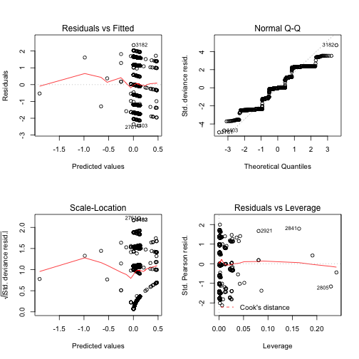

```r
par(mfrow = c(2, 2))
plot(sr.glm)
```

In the reduced model, none of the predictors is significant at the 0.05 level, though cwd status is close, and suggests that cwd-positive deer may be more likely to have male offspring than cwd-negative deer.

```r
(nMale = sum(deerF1$maleNo, na.rm = T))
```

```
## [1] 2347
```

```r
(nFemale = sum(deerF1$femaleNo, na.rm = T))
```

```
## [1] 2220
```

```r
nMale / nFemale
```

```
## [1] 1.057207
```

```r
se = function(p, n) {
    return (sqrt(p * (1 - p) / n))
}

propMTot = nMale / (nMale + nFemale)
seTot = se(propMTot, (nMale + nFemale))


(nMaleYr = tapply(deerF1$maleNo, deerF1$year, sum, na.rm = T))
```

```
## 2003 2004 2005 2006 2007 2008 2009 2010 2011 2012
##   36  191  198  268  317  388  259  166  327  197
```

```r
(nFemaleYr = tapply(deerF1$femaleNo, deerF1$year, sum, na.rm = T))
```

```
## 2003 2004 2005 2006 2007 2008 2009 2010 2011 2012
##   25  194  166  242  317  357  227  184  311  197
```

```r
(round(nMaleYr / nFemaleYr, 2))
```

```
## 2003 2004 2005 2006 2007 2008 2009 2010 2011 2012
## 1.44 0.98 1.19 1.11 1.00 1.09 1.14 0.90 1.05 1.00
```

```r
(propMale = nMaleYr / (nMaleYr + nFemaleYr))
```

```
##      2003      2004      2005      2006      2007      2008      2009
## 0.5901639 0.4961039 0.5439560 0.5254902 0.5000000 0.5208054 0.5329218
##      2010      2011      2012
## 0.4742857 0.5125392 0.5000000
```

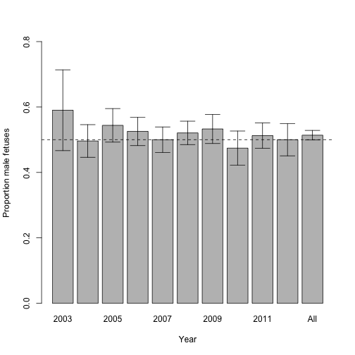

```r
propMaleSEs = se(propMale, (nMaleYr + nFemaleYr))

barplot(c(propMale, All = propMTot), xlab = 'Year',
        ylab = 'Proportion male fetuses',
        ylim = c(0, 0.8))
abline(h = 0.5, lty = 2)
# width = 1, space = 0.2
xs = seq(0.2 + 0.5, by = 1.2, length = 11)
arrows(xs, c(propMale, propMTot),
       xs, c(propMale + 1.96*percMaleSEs, propMTot + 1.96*seTot),
       angle = 90, length = 0.15)
arrows(xs, c(propMale, propMTot),
       xs, c(propMale - 1.96*percMaleSEs, propMTot - 1.96*seTot),
       angle = 90, length = 0.15)
```

The graph shows the proportion of male fetuses each year ± 1.96 SE (95% confidence interval).

Looking just at the numbers of male and female fetuses, we see that over our entire data set, males are slightly more prevalent than females (51.4% or a M:F ration of 1.06), though this value just misses significance at the 95% confidence level. Looking at each year individually, no year differed significantly from the 50% proportion, nor did any year differ significantly from any other year.

Go on to analysis of affect on fetal sizes.